# Take-home Exercise 1

Programming Elegant DataVis with tidyverse and ggplot2 R packages

Raveena Chakrapani https://www.linkedin.com/in/raveena-chakrapani-444a60174/ (School Of Computing and Information Systems, Singapore Management University)https://scis.smu.edu.sg/master-it-business  
2022-06-12

# 1.Overview

In this Take-home Exercise 1, I have explored demographic of the [city of Engagement, Ohio USA](https://vast-challenge.github.io/2022/) by using appropriate statistical graphic methods in R. The data is processed by using [**tidyverse**](https://www.tidyverse.org/packages/) family of packages and the statistical graphics are prepared by using [**ggplot2**](https://ggplot2.tidyverse.org/) and its extensions.

# 2.Task

Lets breakdown the demographic analysis into individual components and try to answer the following questions  
1. Which category residents are more jovial?  
2. Are the residents with specific educational qualification shares similar interest group ?  
3. What’s the most common educational qualification among the residents?

# 3.Getting Started

### 3.1 Data

The dataset used in this exercise is *Participants.csv* file which contains information about the residents such as age, educationlevel, household size etc., Link to download the dataset is found below

Download Participants.csv

### 3.2 Installing and loading the required libraries

The code chunk below is used to install and load the required packages onto RStudio.

```r
packages = c('tidyverse','ggplot2','dplyr','plotrix','plyr','patchwork','ggthemes')
for(p in packages){
  if(!require(p, character.only = T)){
    install.packages(p)
  }
  library(p, character.only = T)
}
```

### 3.3 Importing Data

```r
# read csv file
data <- read.csv("data/Participants.csv")
head(data)
```

```
  participantId householdSize haveKids age      educationLevel
1             0             3     TRUE  36 HighSchoolOrCollege
2             1             3     TRUE  25 HighSchoolOrCollege
3             2             3     TRUE  35 HighSchoolOrCollege
4             3             3     TRUE  21 HighSchoolOrCollege
5             4             3     TRUE  43           Bachelors
6             5             3     TRUE  32 HighSchoolOrCollege
  interestGroup   joviality
1             H 0.001626703
2             B 0.328086500
3             A 0.393469590
4             I 0.138063446
5             H 0.857396691
6             D 0.772957791
```

### 4. Which category residents are more jovial?

### 4.1 Sketch of Proposed Design

The below figure shows the proposed sketch

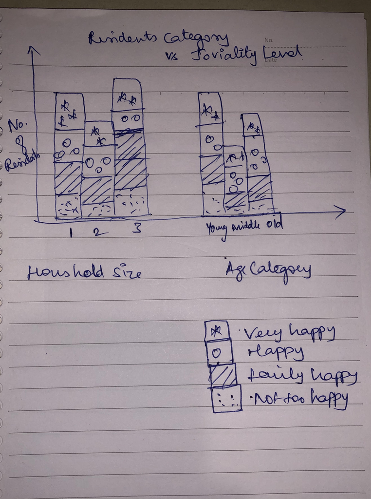